# Project: Practical Machine Learning

Fan Zhang

September 21, 2014

I select Random Forests as the predicting method for two reasons: * given the data set, we are using both numerical and categorical variable for classification; * Random Forests is one of the two most accurate method for such purposes.

```r
# load data
download.file("https://d396qusza40orc.cloudfront.net/predmachlearn/pml-training.csv","train.csv",method = "curl")
download.file("https://d396qusza40orc.cloudfront.net/predmachlearn/pml-testing.csv","test.csv",method = "curl")

training <- read.csv("train.csv", head = T)
test <- read.csv("test.csv", head = T)
```

As a general rule of machine learning, I selected as many meaningful variables as possible, as the predictors in the model. I ran the codes at follow to remove variables with too many NAs and blanks, after which 59 variables remained (including “classe”, the outcome variable). The same treatment was applied to test data set as well.

```r
na.count <- apply(is.na(training) | training == "", 2,sum)
training <- training[,names(na.count[na.count < 19000])][,-1] # remove the row number
test <- test[,colnames(test) %in% names(na.count[na.count < 19000])] [,-1] # remove the row number
colnames(training)
```

```
##  [1] "user_name"            "raw_timestamp_part_1" "raw_timestamp_part_2"
##  [4] "cvtd_timestamp"       "new_window"           "num_window"
##  [7] "roll_belt"            "pitch_belt"           "yaw_belt"
## [10] "total_accel_belt"     "gyros_belt_x"         "gyros_belt_y"
## [13] "gyros_belt_z"         "accel_belt_x"         "accel_belt_y"
## [16] "accel_belt_z"         "magnet_belt_x"        "magnet_belt_y"
## [19] "magnet_belt_z"        "roll_arm"             "pitch_arm"
## [22] "yaw_arm"              "total_accel_arm"      "gyros_arm_x"
## [25] "gyros_arm_y"          "gyros_arm_z"          "accel_arm_x"
## [28] "accel_arm_y"          "accel_arm_z"          "magnet_arm_x"
## [31] "magnet_arm_y"         "magnet_arm_z"         "roll_dumbbell"
## [34] "pitch_dumbbell"       "yaw_dumbbell"         "total_accel_dumbbell"
## [37] "gyros_dumbbell_x"     "gyros_dumbbell_y"     "gyros_dumbbell_z"
## [40] "accel_dumbbell_x"     "accel_dumbbell_y"     "accel_dumbbell_z"
## [43] "magnet_dumbbell_x"    "magnet_dumbbell_y"    "magnet_dumbbell_z"
## [46] "roll_forearm"         "pitch_forearm"        "yaw_forearm"
## [49] "total_accel_forearm"  "gyros_forearm_x"      "gyros_forearm_y"
## [52] "gyros_forearm_z"      "accel_forearm_x"      "accel_forearm_y"
## [55] "accel_forearm_z"      "magnet_forearm_x"     "magnet_forearm_y"
## [58] "magnet_forearm_z"     "classe"
```

Then I used randomForest() in randomForest package to train the data.

```r
library(randomForest)
set.seed(1234)
fit <- randomForest(classe~., ntree = 300, importance = T, proximity = T, data = training)
```

```r
importance(fit)
```

```
##                           A        B      C       D         E
## user_name             9.949 11.47031 10.225 10.1937 11.254739
## raw_timestamp_part_1 32.207 40.75708 42.418 33.5392 27.431274
## raw_timestamp_part_2  7.155 10.31199 10.752  9.1283  6.006581
## cvtd_timestamp       36.123 44.42908 46.291 51.1142 35.268043
## new_window           -1.002 -0.03033 -1.266  0.5537  0.005321
## num_window           21.918 30.38357 31.509 23.5792 23.346425
## roll_belt            22.184 25.95504 24.230 25.0337 23.470518
## pitch_belt           15.208 23.40607 21.529 20.1266 17.904651
## yaw_belt             22.349 23.82203 23.615 24.1110 16.588860
## total_accel_belt     10.437 10.11999 10.644 10.4053  9.638320
## gyros_belt_x          9.741  8.89916 10.624  9.1062 10.344484
## gyros_belt_y          5.337  8.63395  9.480 10.2465 10.526183
## gyros_belt_z         11.393 13.22282 14.159 15.5529 14.349998
## accel_belt_x          9.715  9.65014 10.101  9.3544  9.339535
## accel_belt_y          7.470  7.93922  8.364 10.8522  7.908579
## accel_belt_z         13.661 14.10579 14.106 12.8468 12.580467
## magnet_belt_x         9.870 16.64704 14.636 13.2821 13.345368
## magnet_belt_y        11.886 14.07432 14.357 18.1502 14.917773
## magnet_belt_z        11.731 13.58655 12.226 19.6502 13.341339
## roll_arm             11.918 17.52901 16.432 14.4159 13.316699
## pitch_arm             9.397 14.25803 11.131 10.7086  8.042830
## yaw_arm              11.121 15.34970 13.152 12.6525 10.116461
## total_accel_arm       6.609 11.47778  9.654  8.7543  9.338233
## gyros_arm_x           8.729 12.61409 13.142 12.4677  8.790138
## gyros_arm_y           9.830 14.78665 14.554 13.1256 11.116544
## gyros_arm_z           7.726 11.48940  8.013  7.8815  6.345641
## accel_arm_x          10.052 11.38237 11.495 10.7883  9.657604
## accel_arm_y           8.495 10.87591  9.667  9.8278 10.346168
## accel_arm_z           7.874  9.02610  9.995  9.9231  8.307854
## magnet_arm_x         10.953 10.67875  9.998  9.7827  9.388863
## magnet_arm_y          7.721  9.51996 10.313 10.6669  7.696405
## magnet_arm_z         10.656 15.38963 13.332 11.3430 11.694226
## roll_dumbbell        13.258 15.29479 19.475 16.9804 14.930158
## pitch_dumbbell        7.742 11.36607 10.846  8.7190  8.783045
## yaw_dumbbell          9.691 12.65067 14.040 13.1960 12.018981
## total_accel_dumbbell 10.995 14.48639 13.099 12.0514 12.439188
## gyros_dumbbell_x      9.274 12.84596 13.216 10.8735  8.551380
## gyros_dumbbell_y     11.894 12.18562 15.464 12.3427 11.100662
## gyros_dumbbell_z      9.500 12.65809 10.270  9.9513  7.156876
```

[output cut: 63 more lines]

```
## magnet_dumbbell_y                 23.8295         537.3807
## magnet_dumbbell_z                 24.4727         500.4490
## roll_forearm                      15.6014         367.2413
## pitch_forearm                     21.3784         498.6645
## yaw_forearm                       16.3372          82.1769
## total_accel_forearm               13.0715          48.9668
## gyros_forearm_x                   17.0316          33.7155
## gyros_forearm_y                   16.2701          65.1577
## gyros_forearm_z                   15.8777          42.2288
## accel_forearm_x                   14.5934         204.9908
## accel_forearm_y                   14.5512          73.8654
## accel_forearm_z                   16.6041         157.8789
## magnet_forearm_x                  15.7108         106.5906
## magnet_forearm_y                  17.3358         109.4046
## magnet_forearm_z                  19.3280         132.8708
```

Hence I plotted to check if the relationship is valid.

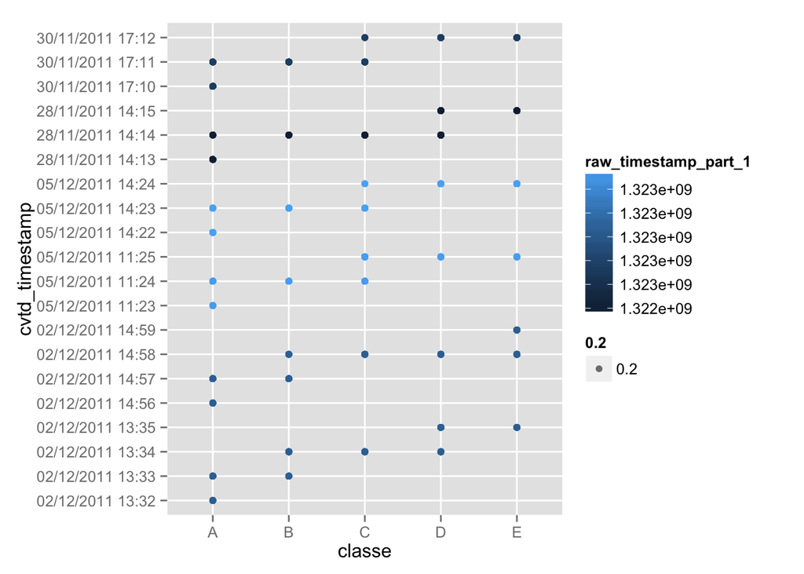

```r
library(ggplot2)
qplot(classe,cvtd_timestamp, data = training, col = raw_timestamp_part_1, alpha = .2)
```

From the plot, a repeated pattern is observed. Measured by cvtd_timestamp and raw_timestamp_part_1, during an interval of 2 minutes, either 1 or 2 records are sequentially assigned to A - E classes, the pattern repeated every 7 or 8 records. In pratical sense, such a pattern may result from the timely mismatch of the steamlines. That is, though multiple steamlines producing works simultaneously with same speed, at they may not started at the same time, so that the time lag is observed and repeated.

We then checked the fit result.

```r
fit
```

```
##
## Call:
##  randomForest(formula = classe ~ ., data = training, ntree = 300,      importance = T, proximity = T)
##                Type of random forest: classification
##                      Number of trees: 300
## No. of variables tried at each split: 7
##
##         OOB estimate of  error rate: 0.07%
## Confusion matrix:
##      A    B    C    D    E class.error
## A 5579    1    0    0    0   0.0001792
## B    2 3795    0    0    0   0.0005267
## C    0    4 3417    1    0   0.0014611
## D    0    0    3 3212    1   0.0012438
## E    0    0    0    1 3606   0.0002772
```

```r
Fit <- rfcv(training[,-59],training$classe, ntree = 300)# random forest with cross validation

Fit$error.cv
```

```
##        58        29        14         7         4         1
## 0.0010193 0.0008154 0.0006625 0.0004077 0.0025991 0.4137193
```

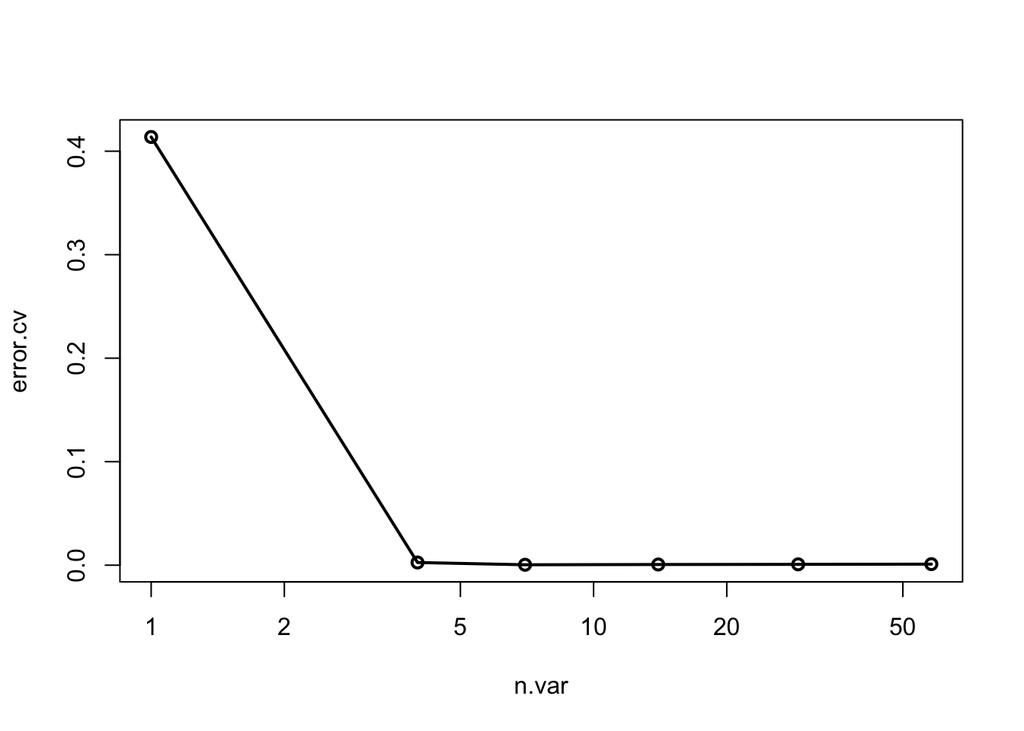

```r
with(Fit, plot(n.var, error.cv, log="x", type="o", lwd=2))
```

We are now certain that at least number of variables tried at each split is unchanged from the orignial model. Since the same seed is used, we can ensure that the whole tree structure is unaltered as well. Hence the OOB is validated.

Finally we print the prediction.

```r
test$classe <- "A"
data <- rbind(training,test) # to get rid of class mismatch error

pred <- as.character(predict(fit, newdata = tail(data, n = 20)))
pred
```

```
##  [1] "B" "A" "B" "A" "A" "E" "D" "B" "A" "A" "B" "C" "B" "A" "E" "E" "A"
## [18] "B" "B" "B"
```